# Practical Machine Learning - Prediction Assignment

W. Mangrobang

April 17, 2018

### Executive Summary

We have been provided training and testing data on 6 study participants, who were asked to lift barbells correctly and incorrectly in 5 different ways. We are tasked with using this data to predict the manner in which they did the exercise. A random forest model was built that was able to predict the exercises with an accuracy rate of about 99%.

### Exploratory Analysis

From just looking at a few rows and performing a **summary** and a **str**, it appeared that many of the columns were likely missing most or all values. These empty or sparse columns could probably be excluded from the analysis.

Here is a plot of the percent of values that are missing for each of the 160 variables:

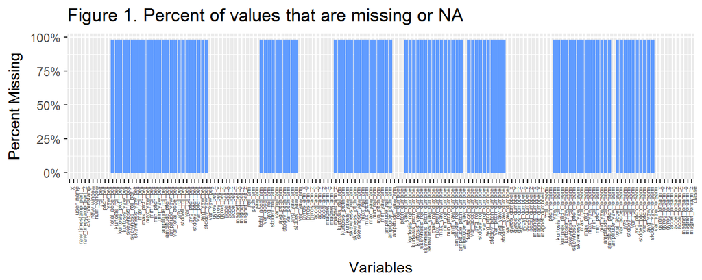

This suggests we can cull many variables from our analysis. Moreso, it appears that it is basically all or nothing for variables; either there are no missing values at all, or it’s almost 100% missing. So I decided to scrub out the variables that were almost all missing, and kept the ones where none are missing.

That removed 100 variables, so we were left with 60 left to analyze. I continued to analyze the remaining variables to see if any could be removed.

After performing another **str**,**summary**, etc., it looked like some variables were administrative in nature, and thus shouldn’t have a true impact on the results (or would bias the results). Thus the following variables were then also removed:

- `X`: Looks simply to be a row index.
- `user_name`: Self-explanatory.
- `raw_timestamp_part_1`, `raw_timestamp_part_2`, `cvtd_timestamp`: Various timestamps.
- `new_window`, `num_window`: Seems to be other administrative variables.

Luckily they all lined up in the first 7 variables, so they were easily lasered out.

We then took another look at the 53 remaining variables:

```
## 'data.frame':    19622 obs. of  10 variables:
##  $ roll_belt       : num  1.41 1.41 1.42 1.48 1.48 1.45 1.42 1.42 1.43 1.45 ...
##  $ pitch_belt      : num  8.07 8.07 8.07 8.05 8.07 8.06 8.09 8.13 8.16 8.17 ...
##  $ yaw_belt        : num  -94.4 -94.4 -94.4 -94.4 -94.4 -94.4 -94.4 -94.4 -94.4 -94.4 ...
##  $ total_accel_belt: int  3 3 3 3 3 3 3 3 3 3 ...
##  $ gyros_belt_x    : num  0 0.02 0 0.02 0.02 0.02 0.02 0.02 0.02 0.03 ...
##  $ gyros_belt_y    : num  0 0 0 0 0.02 0 0 0 0 0 ...
##  $ gyros_belt_z    : num  -0.02 -0.02 -0.02 -0.03 -0.02 -0.02 -0.02 -0.02 -0.02 0 ...
##  $ accel_belt_x    : int  -21 -22 -20 -22 -21 -21 -22 -22 -20 -21 ...
##  $ accel_belt_y    : int  4 4 5 3 2 4 3 4 2 4 ...
##  $ accel_belt_z    : int  22 22 23 21 24 21 21 21 24 22 ...
```

```r
# Etc...
```

Dataset looked pretty meaningful at this point, as there did not appear to be any missing values or obvious weird values. So then we moved on to modeling!

### Model Fitting and Selection

For partitioning out my data into train and test sets, I decided on a 70%/30% split, as that appears to be a common rule of thumb among data science practitioners. 70% also felt the largest I wanted to run as training set because my intution was that any larger would have been too resource intensive, and also would lend to overfitting.

Here is the training result:

```
## Random Forest
##
## 13737 samples
##    52 predictor
##     5 classes: 'A', 'B', 'C', 'D', 'E'
##
## No pre-processing
## Resampling: Cross-Validated (10 fold)
## Summary of sample sizes: 12363, 12362, 12362, 12365, 12362, 12364, ...
## Resampling results across tuning parameters:
##
##   mtry  Accuracy   Kappa
##    2    0.9928652  0.9909744
##   27    0.9927924  0.9908822
##   52    0.9844933  0.9803836
##
## Accuracy was used to select the optimal model using the largest value.
## The final value used for the model was mtry = 2.
```

The resulting models look highly accurate! The final model was settled at **mtry=2**.

For cross validation I used k-fold cross validation. I selected this because it is the best avenue to minimize bias and variance error. Based on researching other findings and opinions of other data science practitioners on what the ‘optimal’ k should be, I selected 10 as an accepted standard to balancing computational and time requirements (this project is constrained by limited computational resources and time), as well as balancing the bias vs. variance trade-off.

Here is the confusion matrix:

```
##
## Call:
##  randomForest(x = x, y = y, mtry = param$mtry, proximity = TRUE,      allowParallel = TRUE)
##                Type of random forest: classification
##                      Number of trees: 500
## No. of variables tried at each split: 2
##
##         OOB estimate of  error rate: 0.66%
## Confusion matrix:
##      A    B    C    D    E class.error
## A 3902    4    0    0    0 0.001024066
## B   10 2643    5    0    0 0.005643341
## C    0   20 2372    4    0 0.010016694
## D    0    0   39 2209    4 0.019094139
## E    0    0    3    2 2520 0.001980198
```

For random forests the out-of-sample error can be represented by the out-of-bag (OOB) error. In this case it is 0.66%, suggesting a very accurate model. Also of note is that random forest out-of-bag error can also be considered a proxy for cross-validation error.

In addition to that I had held out 30% of the data for testing. So I will run the final model on that data set and see if resulting error of its predictions is comparable to the above OOB error.

Here is the confusion matrix and statistics for the scoring of that 30% test set:

```
## Confusion Matrix and Statistics
##
##           Reference
## Prediction    A    B    C    D    E
##          A 1674    7    0    0    0
##          B    0 1129    6    0    0
##          C    0    3 1020   15    0
##          D    0    0    0  949    3
##          E    0    0    0    0 1079
##
## Overall Statistics
##
##                Accuracy : 0.9942
##                  95% CI : (0.9919, 0.996)
##     No Information Rate : 0.2845
##     P-Value [Acc > NIR] : < 2.2e-16
##
##                   Kappa : 0.9927
##  Mcnemar's Test P-Value : NA
##
## Statistics by Class:
##
##                      Class: A Class: B Class: C Class: D Class: E
## Sensitivity            1.0000   0.9912   0.9942   0.9844   0.9972
## Specificity            0.9983   0.9987   0.9963   0.9994   1.0000
## Pos Pred Value         0.9958   0.9947   0.9827   0.9968   1.0000
## Neg Pred Value         1.0000   0.9979   0.9988   0.9970   0.9994
## Prevalence             0.2845   0.1935   0.1743   0.1638   0.1839
## Detection Rate         0.2845   0.1918   0.1733   0.1613   0.1833
## Detection Prevalence   0.2856   0.1929   0.1764   0.1618   0.1833
## Balanced Accuracy      0.9992   0.9950   0.9952   0.9919   0.9986
```

So the accuracy of the test set is 99.4%, or in other words the out-of-sample error is 0.58%. Very close to the OOB error! Because they are so close I feel very good about this model.

### Conclusion

Given the exercise data that was provided to use, we were able to build a random forest classification model that was able to accurately predict the type of exercise that was being performed, 99% of the time.